# Evaluating Performance Across Europe's Elite Soccer Leagues

## Author: Nathan Sankar

## Date: 04/28/2023

#### Association football, also known as soccer in the United States, is the most popular sport in the world, with an estimated 3.5 billion fans globally. Soccer is not only a hobby for millions of people but it is also a multi-billion dollar industry, with teams and players from around the world competing for fame and millions of dollars of rewards.

#### One of the most unique aspects of soccer is the competitive and unpredictable nature of the sport. While some teams may appear to be a stronger team on paper, the outcome of a match is often determined by a variety of factors, including the skill of the players, the tactics of the coach, and the performance of the team as a whole. This makes soccer a fascinating sport to analyze and study, as it provides a unique opportunity to explore the dynamics of team performance and the factors that contribute to success. If you are new to soccer, you can learn more about the rules of the sport [here](https://ussoccerplayers.com/beginners-guide-to-soccer).

#### In this project, I aim to compare the best soccer teams in the five best leagues in Europe, including the English Premier League, La Liga in Spain, Bundesliga in Germany, Serie A in Italy, and Ligue 1 in France. By analyzing and comparing the performance of the top teams in each league, we can identify which teams are performing the best overall and draw many other interesting insights about the sport. I will also talk about European soccer competitions and [here](https://en.wikipedia.org/wiki/UEFA_club_competitions) is a link that will help those who do not know much about European soccer and the UEFA competitions.

#### This data science project is not only valuable for fans and enthusiasts of the sport, but it also has practical applications in sports betting, player recruitment, and it could also act as a guide for those who want to become more involved in soccer. By analyzing the performance of the best teams in different leagues, we can gain insights into the performance of top-tier soccer teams, and identify trends and patterns that can inform strategy and decision-making in a variety of different situations. This project wil also demonstrate the useful of data science. Millions of dollars are spend on collecting data during and after socer games. However, modeling the data and representing the data in a graph or another visual makes the data much more useful. This project will help use readily avaible data and make it more useful for the general public and even for professionals. Additionally, it will also show the art of data science as it will show how the steps to gather data, clean the data, making visuals, and makeing models can help make conclusions. Since football is the name that is used to refer to soccer in most countries, I will use the term football throughout this project.

#### Throughout this project I will show how I was able to get my data, present it, and come to conclusions through the [Data Science Lifecyle](https://www.geeksforgeeks.org/data-science-lifecycle/).

#### Since this project requires the use of a lot of different libraries and technologies, here are som of those technologies and librariess: Python, Pandas, Numpy, Matplotlib, Seaborn, Scikit-learn, SQLite, Plotly, and Matplotlib.

### Imports

```python
import numpy as np
import pandas as pd
import seaborn as sns
import matplotlib.pyplot as plt
import requests
from bs4 import BeautifulSoup
import plotly.express as px
from sklearn import linear_model
import statsmodels.formula.api as smf
from sklearn.cluster import KMeans
import plotly.graph_objs as go
from plotly.subplots import make_subplots
from sklearn.ensemble import RandomForestRegressor
from sklearn.model_selection import train_test_split
from sklearn.metrics import mean_squared_error


pd.set_option('display.max_columns', None)
import plotly.io as pio
pio.renderers.default = "notebook+plotly_mimetype+png+jpeg+svg+pdf"


# Display all rows
pd.set_option('display.max_rows', None)
```

## Data Collection

#### The first step of the data science process is to gather data. While some data might be easily accessible, other data might be more difficult to obtain. In this project, I will be using data from the following sources: [FBREF](https://fbref.com/en/), and [Transfer Markt](https://www.transfermarkt.com/). FBREF is a website that provides detailed statistics about football matches, players, and teams. Transfer Markt is a website that provides information about the transfer market, including the transfer fees of players and the market value of teams.

#### An important piece of information about football is the 5 main leagues in soccer. While there are many leagues throughout the world in countries like the USA, Spain, Saudi Arabia, and China, the top 5 leagues are the English Premier League, La Liga in Spain, Bundesliga in Germany, Serie A in Italy, and Ligue 1 in France. These leagues are considered the best in the world and they are the most popular and most watched leagues in the world. Even though there are many other leagues in the world, I will be focusing on these 5 leagues in this project because the vast majority of football watchers watch them.

#### The first part of data collection that I did was to import several CSV files that had basic statistics about the 5 leagues. These data tables varied from general information about a football league to having detailed defensive information or offensive statistics about a league. Then, I cleaned the data and put it into a data frame so that it becomes more accessible and easier to work with. Cleaning data is the process in which data in a dataset is fixed and all inconsistencies and errors are removed in order to analyze the data. This article can better explain [data cleaning](https://www.tableau.com/learn/articles/what-is-data-cleaning#:~:text=Data%20cleaning%20is%20the%20process,incomplete%20data%20within%20a%20dataset.). Additionally, a [data frame](https://www.w3schools.com/python/pandas/pandas_dataframes.asp) is a 2D table structure that is able to store information and access information in a convenient way that makes analyzing information easier for a data scientist.

#### I first started by getting some basic statistics on the 5 leauges and putting them into a dataframe.

```python
# Using the data tables from the FBREF websiter, I will be getting the
# general statistics for the 5 major leagues in Europe
df_PL = pd.read_csv('PLStandard.csv', delimiter=',',skiprows=1)
df_LL = pd.read_csv('LLStandard.csv', delimiter=',',skiprows=1)
df_BL = pd.read_csv('BLStandard.csv', delimiter=',',skiprows=1)
df_SA = pd.read_csv('SAStandard.csv', delimiter=',',skiprows=1)
df_L1 = pd.read_csv('L1Standard.csv', delimiter=',',skiprows=1)
df_list = [df_PL, df_LL, df_BL, df_SA, df_L1]

# Cleaning the data by renaming the columns into more understandable names
# x before the stat means expected stat (ex: xG = expected goals) and G means goals, A means
# assists, PK means penalty kicks, npxG means non penalty kicks, PrgC means progressive carries,
# PrgP means progressive passes, 90 means per 90 minutes
column_names = ['Squad', '#OfPlayers', 'Age', 'Poss', 'MatchesPlayed', 'Starts', 'Min', '90s', 'Goals',
       'Asists', 'G+A', 'G-PK', 'PK', 'PKAttempts', 'YCard', 'RCard', 'xG', 'NonPKxG',
       'xAG', 'npxG+xAG', 'PrgC', 'PrgP', 'G/90', 'A/90', 'G+A/90', 'G-PK/90',
       'G+A-PK/90', 'xG/90', 'xAG/90', 'xG+xAG/90', 'npxG/90', 'npxG+xAG/90']

df_PL.columns = column_names
for df in df_list:
    df.columns = column_names

# Adding a column for the league name
df_PL["League"] = "Premier Leauge"
df_LL["League"] = "La Liga"
df_BL["League"] = "Bundesliga"
df_SA["League"] = "Serie A"
df_L1["League"] = "Ligue 1"

# Combining all the dataframes into one
df_Gen = pd.concat([df_PL, df_LL, df_BL, df_SA, df_L1], ignore_index=True)
df_Gen.head(5)
```

|  | Squad | #OfPlayers | Age | Poss | MatchesPlayed | Starts | Min | 90s | Goals | Asists | G+A | G-PK | PK | PKAttempts | YCard | RCard | xG | NonPKxG | xAG | npxG+xAG | PrgC | PrgP | G/90 | A/90 | G+A/90 | G-PK/90 | G+A-PK/90 | xG/90 | xAG/90 | … |
| --- | --- | --- | --- | --- | --- | --- | --- | --- | --- | --- | --- | --- | --- | --- | --- | --- | --- | --- | --- | --- | --- | --- | --- | --- | --- | --- | --- | --- | --- | --- |
| 0 | Arsenal | 26 | 25.4 | 59.9 | 34 | 374 | 3060 | 34.0 | 78 | 59 | 137 | 75 | 3 | 4 | 47 | 0 | 66.3 | 63.5 | 48.8 | 112.3 | 744 | 1877 | 2.29 | 1.74 | 4.03 | 2.21 | 3.94 | 1.95 | 1.44 | … |
| 1 | Aston Villa | 26 | 27.8 | 49.6 | 34 | 374 | 3060 | 34.0 | 44 | 31 | 75 | 41 | 3 | 3 | 65 | 1 | 43.4 | 41.1 | 33.4 | 74.5 | 548 | 1120 | 1.29 | 0.91 | 2.21 | 1.21 | 2.12 | 1.28 | 0.98 | … |
| 2 | Bournemouth | 31 | 27.1 | 39.9 | 34 | 374 | 3060 | 34.0 | 36 | 23 | 59 | 36 | 0 | 0 | 61 | 0 | 35.6 | 35.6 | 25.8 | 61.3 | 452 | 887 | 1.06 | 0.68 | 1.74 | 1.06 | 1.74 | 1.05 | 0.76 | … |
| 3 | Brentford | 25 | 27.0 | 43.9 | 34 | 374 | 3060 | 34.0 | 50 | 30 | 80 | 43 | 7 | 8 | 49 | 1 | 50.6 | 44.4 | 33.6 | 78.0 | 332 | 1024 | 1.47 | 0.88 | 2.35 | 1.26 | 2.15 | 1.49 | 0.99 | … |
| 4 | Brighton | 27 | 27.4 | 60.2 | 32 | 352 | 2880 | 32.0 | 58 | 38 | 96 | 52 | 6 | 6 | 43 | 0 | 61.8 | 57.5 | 43.7 | 101.2 | 680 | 1579 | 1.81 | 1.19 | 3.00 | 1.62 | 2.81 | 1.93 | 1.37 | … |

#### Next I focused on getting statistics on specific aspects of the sport incldung the offense (df_LeaugeName_Off), defense (df_LeaugeName_D) and putting it into a dataframe and merging it with the main dataframe. I horizontally concatanted all the offensive dataframes and defensive dataframes together and put them into their respective combined dataframes. Horizontally [concatanting](https://pandas.pydata.org/docs/reference/api/pandas.concat.html) a data frame is when you combine 2 data frames in which the row values remain the same, but more columns are added and those rows are updated with the extra information for those columns.

```python
# Offense Data
df_PL_Off = pd.read_csv('PLOff.csv', delimiter=',',skiprows=1)
df_LL_Off = pd.read_csv('LLOff.csv', delimiter=',',skiprows=1)
df_BL_Off = pd.read_csv('BLOff.csv', delimiter=',',skiprows=1)
df_SA_Off = pd.read_csv('SAOff.csv', delimiter=',',skiprows=1)
df_L1_Off = pd.read_csv('L1Off.csv', delimiter=',',skiprows=1)
df_list_Off = [df_PL_Off, df_LL_Off, df_BL_Off, df_SA_Off, df_L1_Off]

column_names_Off = ['Squad', '#OfPlayers', '90s', "Shot_Creating_Actions", "SCA/90", "PassLive",
                    "PassDead", "TakeOnsTS", "ShotTS", "FoulTS", "DefTS", "Goal_Creating_Actions",
                    "GCA/90", "PassLiveG", "PassDeadG", "TakeOnG", "ShotG", "FoulG", "DefG"]

for value in df_list_Off:
    value.columns = column_names_Off

    # Cleaning the data frame by droping unnessiary columns
    value.drop(["PassLiveG", "PassDeadG", "TakeOnG", "ShotG", "FoulG", "DefG", '#OfPlayers', '90s'], axis=1, inplace=True)

# Creating a new dataframe with the offense data
df_Off = pd.concat(df_list_Off, ignore_index=True)
df_Off.head(5)
```

|  | Squad | Shot_Creating_Actions | SCA/90 | PassLive | PassDead | TakeOnsTS | ShotTS | FoulTS | DefTS | Goal_Creating_Actions | GCA/90 |
| --- | --- | --- | --- | --- | --- | --- | --- | --- | --- | --- | --- |
| 0 | Arsenal | 982 | 28.06 | 723 | 75 | 54 | 72 | 41 | 17 | 141 | 4.03 |
| 1 | Aston Villa | 701 | 20.03 | 534 | 46 | 43 | 37 | 32 | 9 | 74 | 2.11 |
| 2 | Bournemouth | 577 | 16.49 | 417 | 42 | 50 | 41 | 21 | 6 | 64 | 1.83 |
| 3 | Brentford | 627 | 17.91 | 424 | 89 | 28 | 37 | 44 | 5 | 86 | 2.46 |
| 4 | Brighton | 905 | 28.28 | 688 | 62 | 68 | 52 | 24 | 11 | 100 | 3.12 |

```python
# Defense Data
df_PL_D = pd.read_csv('PLDef.csv', delimiter=',',skiprows=1)
df_LL_D = pd.read_csv('LLDef.csv', delimiter=',', skiprows=1)
df_BL_D = pd.read_csv('BLDef.csv', delimiter=',', skiprows=1)
df_SA_D = pd.read_csv('SADef.csv', delimiter=',', skiprows=1)
df_L1_D = pd.read_csv('L1Def.csv', delimiter=',',skiprows=1)
d_column_names = ['Squad', '#Pl', '90s', 'Tackles', 'TacklesW', 'Def_3rd', 'Mid_3rd', 'Att_3rd',
                  'Tkl', 'Att', 'Tkl%', 'Lost', 'Blocks', 'ShotBlock', 'PassBlock',
                  'Interceptions', 'Tkl+Int', 'Clrearances', 'Errors']

for dfvalue in [df_PL_D, df_LL_D, df_BL_D, df_SA_D, df_L1_D]:
    dfvalue.columns = d_column_names
    dfvalue.drop(['#Pl', '90s', 'Tkl+Int', 'ShotBlock', 'PassBlock', 'Tkl%',"Lost"], axis=1, inplace=True)

# Creating a new dataframe with the defense data
df_Def = pd.concat([df_PL_D, df_LL_D, df_BL_D, df_SA_D, df_L1_D], ignore_index=True)
df_Def.head(5)
```

|  | Squad | Tackles | TacklesW | Def_3rd | Mid_3rd | Att_3rd | Tkl | Att | Blocks | Interceptions | Clrearances | Errors |
| --- | --- | --- | --- | --- | --- | --- | --- | --- | --- | --- | --- | --- |
| 0 | Arsenal | 500 | 302 | 213 | 185 | 102 | 215 | 424 | 320 | 214 | 540 | 19 |
| 1 | Aston Villa | 569 | 302 | 278 | 223 | 68 | 284 | 574 | 401 | 278 | 633 | 12 |
| 2 | Bournemouth | 558 | 338 | 282 | 226 | 50 | 226 | 526 | 451 | 310 | 918 | 9 |
| 3 | Brentford | 528 | 303 | 245 | 209 | 74 | 230 | 544 | 393 | 314 | 745 | 11 |
| 4 | Brighton | 538 | 297 | 236 | 211 | 91 | 232 | 461 | 336 | 268 | 368 | 14 |

#### Additionally, I also got more generalized data on the top 5 leagues and put it into a dataframe to get even more specific statistics on the teams.

```python
df_5L = pd.read_csv('5L.csv', delimiter=',')

# Removing the name of the top scorer because that is not needed. However, I will be keeping
# number of the goals scored by the top scorer becuase that
# shows how the team's best player is performing which could be a factor in how the team performes
df_5L['Top_Scorer_Goals'] = df_5L['Top Team Scorer'].str.split(' - ', expand=True)[1]
df_5L['Top_Scorer_Goals'] = df_5L['Top_Scorer_Goals'].astype(float)

# Removing the columns that have repeat data or data that I will not use
df_5L.drop(columns=['Last 5','Country','GF','xG','xGA', 'xGD', 'xGD/90',
                    'Top Team Scorer', 'MP', 'Rk', 'Goalkeeper'],axis=1,inplace=True)
df_5L.head(5)
```

|  | Squad | LgRk | W | D | L | GA | GD | Pts | Pts/MP | Attendance | Top_Scorer_Goals |
| --- | --- | --- | --- | --- | --- | --- | --- | --- | --- | --- | --- |
| 0 | Barcelona | 1 | 26 | 4 | 3 | 11 | 49 | 82 | 2.48 | 82920 | 19.0 |
| 1 | Napoli | 1 | 25 | 5 | 3 | 23 | 46 | 80 | 2.42 | 24058 | 22.0 |
| 2 | Manchester City | 1 | 25 | 4 | 4 | 30 | 57 | 79 | 2.39 | 53226 | 35.0 |
| 3 | Arsenal | 2 | 24 | 6 | 4 | 39 | 42 | 78 | 2.29 | 60200 | 15.0 |
| 4 | Paris S-G | 1 | 24 | 3 | 6 | 34 | 42 | 75 | 2.27 | 38125 | 23.0 |

#### Lastly, for the data collection part of the project, I gathered data on the total market value of each team in each league and put it into a dataframe, which I merged with the main dataframe to get a better understanding of the market value of each team in each league. I used the library called [Beautiful Soup](https://www.crummy.com/software/BeautifulSoup/bs4/doc/) to scrape the data from the website. I used Beautiful Soup to scrape the data from a website's HTML and put it into a dataframe, which I then merged with the main dataframe to get a better understanding of the market value of each team in each league. [Data scraping](https://www.imperva.com/learn/application-security/data-scraping/#:~:text=Data%20scraping%2C%20or%20web%20scraping,the%20data%20on%20other%20websites.) is when data is extracted from an external source like a website and put it into a table or annother method of storing the data.

#### The getTeamWorth method is a method I created to get the market value of each team in each league. The method takes in a URL for the webpage that the data is on and the header permissions to scrape the data and it returns a dataframe with the market value of each team in that league. I created a method for this situation because I had to do this for each league, and it would be easier to just call the method instead of repeating the same code for each league.

```python
# Method to get the data from the website for the market value of the teams for each of the leagues
def getTeamWorth(url, headers):

    # Using beautiful soup to get the HTML from the website
    response = requests.get(url, headers=headers)
    soup = BeautifulSoup(response.text, 'html.parser')

    # Using beautiful soup methods to get the correct HTML tags that are reuired to scrape the data
    tab = soup.find("table",{"class":"items"})
    tab

    values = tab.findChildren('tbody')
    values

    odd_rows = values[0].find_all("tr", {"class": "odd"})
    even_rows = values[0].find_all("tr", {"class": "even"})
    rows = odd_rows + even_rows
    teams = {}

    # For each of the teams in the wepage I am isolating the team name and the market value of the team
    for row in rows:
        team_name = row.find('td', {'class': 'hauptlink no-border-links'}).a.text
        team_value = row.find_all('td', {'class': 'rechts'})[1].text
        teams[team_name] = team_value
    return teams

url_pl = 'https://www.transfermarkt.com/premier-league/startseite/wettbewerb/GB1'
url_ll = 'https://www.transfermarkt.com/primera-division/startseite/wettbewerb/ES1'
url_bl = 'https://www.transfermarkt.com/bundesliga/startseite/wettbewerb/L1'
url_sa = 'https://www.transfermarkt.com/serie-a/startseite/wettbewerb/IT1'
url_l1 = 'https://www.transfermarkt.com/ligue-1/startseite/wettbewerb/FR1'

headers = {"User-Agent": "Mozilla/5.0 (Macintosh; Intel Mac OS X 10_15_7) "
           "AppleWebKit/537.36 (KHTML, like Gecko) "
           "Chrome/112.0.0.0 Safari/537.36"}

# Creating a dataframe for each leauge with the market value of the teams for each of the leagues
PL_Worth = pd.DataFrame(list(getTeamWorth(url_pl, headers).items()), columns=['Squad', 'Worth'])
LL_Worth = pd.DataFrame(list(getTeamWorth(url_ll, headers).items()), columns=['Squad', 'Worth'])
BL_Worth = pd.DataFrame(list(getTeamWorth(url_bl, headers).items()), columns=['Squad', 'Worth'])
SA_Worth = pd.DataFrame(list(getTeamWorth(url_sa, headers).items()), columns=['Squad', 'Worth'])
L1_Worth = pd.DataFrame(list(getTeamWorth(url_l1, headers).items()), columns=['Squad', 'Worth'])

# Putting the dataframes for each of the leagues into one dataframe and isolating the 2 columns
# that I need
df_worth = pd.concat([PL_Worth, LL_Worth, BL_Worth, SA_Worth, L1_Worth])
df_worth = df_worth[['Squad','Worth']]
df_worth.head(5)
```

|  | Squad | Worth |
| --- | --- | --- |
| 0 | Manchester City | €1.05bn |
| 1 | Arsenal FC | €890.00m |
| 2 | Manchester United | €795.70m |
| 3 | Newcastle United | €494.30m |
| 4 | Leicester City | €443.10m |

#### Due to the fact that I drew data from 2 different sources, I had to merge the dataframes together to get a better understanding of the data in order to make conclusions about the data. When merging data between 2 different data frames you must choose a column to merge the data uppon in which the data will be merged. Additionally, you must choose a method to merge the data. While there are many options, I used a left merge which takes the rows from the left dataframe and matches them the the rows from the right data frame and if there is no corresponding row in the right data frame it will put a null value in its place. However, there are many other types of merges that I did not use in this situation. I chose the team name column to be the column on which I merge the data because it was the only column that was the same in both dataframes and it was a column that I could use as an id column. When I was using the other source and merging the different data tables, it was simple as the entire website used the same formating and same names for the teams. However, the second website I used to collect information had different names for the teams and I had to change the names of the teams in order to merge the data. In order to do this, I created a dictionary that had the old names of the teams contain the new names of the teams and then I used the replace method to change the names of the teams. This all is part of the process of data cleaning which is an essential part of the data science process.

```python
squad_map = {
    '1.FC Köln': 'Köln',
    '1.FC Union Berlin': 'Union Berlin',
    '1.FSV Mainz 05': 'Mainz 05',
    'AC Ajaccio': 'Ajaccio',
    'AC Milan': 'Milan',
    'AC Monza': 'Monza',
    'ACF Fiorentina': 'Fiorentina',
    'AFC Bournemouth': 'Bournemouth',
    'AJ Auxerre': 'Auxerre',
    'AS Monaco': 'Monaco',
    'AS Roma': 'Roma',
    'Angers SCO': 'Angers',
    'Arsenal FC': 'Arsenal',
    'Aston Villa': 'Aston Villa',
    'Atalanta BC': 'Atalanta',
    'Athletic Bilbao': 'Athletic Club',
    'Atlético de Madrid': 'Atlético Madrid',
    'Bayer 04 Leverkusen': 'Leverkusen',
    'Bayern Munich': 'Bayern Munich',
    'Bologna FC 1909': 'Bologna',
    'Borussia Dortmund': 'Dortmund',
    'Borussia Mönchengladbach': "M'Gladbach",
    'Brentford FC': 'Brentford',
    'Brighton & Hove Albion': 'Brighton',
    'CA Osasuna': 'Osasuna',
    'Celta de Vigo': 'Celta Vigo',
    'Chelsea FC': 'Chelsea',
    'Clermont Foot 63': 'Clermont Foot',
    'Crystal Palace': 'Crystal Palace',
    'Cádiz CF': 'Cádiz',
    'ESTAC Troyes': 'Troyes',
    'Eintracht Frankfurt': 'Eint Frankfurt',
    'Elche CF': 'Elche',
    'Everton FC': 'Everton',
    'FC Augsburg': 'Augsburg',
    'FC Barcelona': 'Barcelona',
    'FC Empoli': 'Empoli',
    'FC Lorient': 'Lorient',
    'FC Nantes': 'Nantes',
    'FC Schalke 04': 'Schalke 04',
    'FC Toulouse': 'Toulouse',
    'Fulham FC': 'Fulham',
    'Getafe CF': 'Getafe',
    'Girona FC': 'Girona',
    'Hellas Verona': 'Hellas Verona',
    'Hertha BSC': 'Hertha BSC',
    'Inter Milan': 'Inter',
    'Juventus FC': 'Juventus',
    'LOSC Lille': 'Lille',
    'Leeds United': 'Leeds United',
    'Leicester City': 'Leicester City',
    'Liverpool FC': 'Liverpool',
    'Manchester City': 'Manchester City',
    'Manchester United': 'Manchester Utd',
    'Montpellier HSC': 'Montpellier',
    'Newcastle United': 'Newcastle Utd',
    'Nottingham Forest': "Nott'ham Forest",
    'OGC Nice': 'Nice',
    'Olympique Lyon': 'Lyon',
    'Olympique Marseille': 'Marseille',
    'Paris Saint-Germain': 'Paris S-G',
    'RB Leipzig': 'RB Leipzig',
    'RC Lens': 'Lens',
    'RC Strasbourg Alsace': 'Strasbourg',
    'RCD Espanyol Barcelona': 'Espanyol',
    'RCD Mallorca': 'Mallorca',
    'Real Betis Balompié': 'Betis',
    'Real Madrid': 'Real Madrid',
    'Real Sociedad': 'Real Sociedad',
    'Real Valladolid CF': 'Valladolid',
    'Red Bull Salzburg': 'RB Salzburg',
    'SC Freiburg': 'Freiburg',
    'SD Eibar': 'Eibar',
    'SSC Napoli': 'Napoli',
    'SV Werder Bremen': 'Werder Bremen',
    'Sheffield United': 'Sheffield Utd',
    'Southampton FC': 'Southampton',
    'Stade Brestois 29': 'Brest',
    'Stade Rennais FC': 'Rennes',
    'Stade Reims': 'Reims',
    'Standard de Liège': 'Standard Liège',
    'TSG 1899 Hoffenheim': 'Hoffenheim',
    'Tottenham Hotspur': 'Tottenham',
    'UD Almería': 'Almería',
    'UD Las Palmas': 'Las Palmas',
    'US Lecce': 'Lecce',
    'Valencia CF': 'Valencia',
    'VfB Stuttgart': 'Stuttgart',
    'VfL Bochum': 'Bochum',
    'VfL Wolfsburg': 'Wolfsburg',
    'Villarreal CF': 'Villarreal',
    'West Bromwich Albion': 'West Brom',
    'West Ham United': 'West Ham',
    'Wolverhampton Wanderers': 'Wolves',
    'Águilas Doradas': 'Águilas Doradas',
    'US Cremonese' : 'Cremonese',
    'SS Lazio' : 'Lazio',
    'US Salernitana 1919' : 'Salernitana',
    'UC Sampdo' : 'Sampdo',
    'US Sassuolo' : 'Sassuolo',
    'Sevilla FC' : 'Sevilla',
    'Spezia Calcio' :'Spezia',
    'Torino FC' : 'Torino',
    'Udinese Calcio' : 'Udinese',
    'UC Sampdoria' : 'Sampdoria'
    }
df_worth['Squad'] = df_worth['Squad'].map(squad_map).fillna(df_worth['Squad'])
df_worth.head(5)
```

|  | Squad | Worth |
| --- | --- | --- |
| 0 | Manchester City | €1.05bn |
| 1 | Arsenal | €890.00m |
| 2 | Manchester Utd | €795.70m |
| 3 | Newcastle Utd | €494.30m |
| 4 | Leicester City | €443.10m |

#### Then I merged all the dataframes I got from the previous steps. Merging dataframes is when you put together in a certian way that retains either some or all of the information in both of the original data frames. I merged my dataframes onto the 'Squad' column of my dataframes because the 'Squad' column held the name of the teams, and that stayed costant across all of the data frames. I used the merge method to merge the dataframes. Here is an article that can better explain what the merge method is and how it works: [Merge Method](https://pandas.pydata.org/docs/user_guide/merging.html).

```python
# Merging the general and defense dataframes
df_merge1 = pd.merge(df_Gen, df_Def, on="Squad", suffixes=('', ''))

# Merging the dataframe with the information about the 5 leagues with the dataframe with the general and defense data
df_merge2 = pd.merge(df_merge1, df_5L, on="Squad", suffixes=('', ''))

# Merging the offense dataframe with the dataframe with the information about the 5 league along with the general and defense data
df_merge3 = pd.merge(df_Off, df_merge2, on="Squad", suffixes=('', ''))

# Merging the dataframe with the information about the squad's worth with the dataframe with all the other information
df = pd.merge(df_worth, df_merge3, on="Squad", suffixes=('', ''))
```

#### Annother part of the data cleaning step is done by removing the euro symbol and turning it from a string with a 'm' representing million or 'b' for billion into the actual value to be able to use it for calculations.

```python
def parse_worth(worth):
    if worth.startswith('€') and worth.endswith('m'):
        return float(worth[1:-1]) * 1000000
    elif worth.startswith('€') and worth.endswith('bn'):
        return float(worth[1:-2]) * 1000000000
    else:
        return np.nan

df['Worth'] = df['Worth'].apply(parse_worth)
```

#### Some rows of the final data frame with all the information needed to anaylse

```python
df.sample(n=20)
```

|  | Squad | Worth | Shot_Creating_Actions | SCA/90 | PassLive | PassDead | TakeOnsTS | ShotTS | FoulTS | DefTS | Goal_Creating_Actions | GCA/90 | #OfPlayers | Age | Poss | MatchesPlayed | Starts | Min | 90s | Goals | Asists | G+A | G-PK | PK | PKAttempts | YCard | RCard | xG | NonPKxG | … |
| --- | --- | --- | --- | --- | --- | --- | --- | --- | --- | --- | --- | --- | --- | --- | --- | --- | --- | --- | --- | --- | --- | --- | --- | --- | --- | --- | --- | --- | --- | --- |
| 16 | Everton | 352900000.0 | 651 | 19.15 | 443 | 71 | 33 | 49 | 38 | 17 | 47 | 1.38 | 28 | 27.4 | 43.5 | 34 | 374 | 3060 | 34.0 | 26 | 19 | 45 | 23 | 3 | 3 | 73 | 2 | 38.3 | 35.9 | … |
| 24 | Sevilla | 209000000.0 | 738 | 22.36 | 562 | 68 | 19 | 35 | 37 | 17 | 71 | 2.15 | 33 | 29.5 | 54.4 | 33 | 363 | 2970 | 33.0 | 41 | 26 | 67 | 37 | 4 | 5 | 110 | 11 | 40.0 | 36.3 | … |
| 12 | Tottenham | 680300000.0 | 840 | 24.00 | 643 | 54 | 41 | 50 | 35 | 17 | 104 | 2.97 | 27 | 28.4 | 49.5 | 34 | 374 | 3060 | 34.0 | 61 | 41 | 102 | 57 | 4 | 5 | 70 | 3 | 50.9 | 47.0 | … |
| 44 | Hoffenheim | 154650000.0 | 669 | 21.58 | 480 | 59 | 41 | 36 | 42 | 11 | 74 | 2.39 | 31 | 27.5 | 49.0 | 30 | 330 | 2700 | 30.0 | 38 | 25 | 63 | 33 | 5 | 7 | 72 | 4 | 41.5 | 36.1 | … |
| 58 | Napoli | 629000000.0 | 976 | 28.71 | 714 | 83 | 55 | 63 | 40 | 21 | 120 | 3.53 | 26 | 27.2 | 62.2 | 33 | 363 | 2970 | 33.0 | 67 | 52 | 119 | 61 | 6 | 7 | 42 | 1 | 56.4 | 50.9 | … |
| 67 | Sampdoria | 71450000.0 | 559 | 16.44 | 399 | 43 | 25 | 42 | 36 | 14 | 31 | 0.91 | 37 | 28.6 | 46.8 | 33 | 363 | 2970 | 33.0 | 20 | 16 | 36 | 19 | 1 | 2 | 98 | 3 | 28.5 | 26.9 | … |
| 9 | Fulham | 253500000.0 | 668 | 19.65 | 474 | 66 | 29 | 49 | 38 | 12 | 71 | 2.09 | 29 | 29.0 | 48.1 | 34 | 374 | 3060 | 34.0 | 42 | 25 | 67 | 38 | 4 | 7 | 75 | 1 | 39.8 | 34.3 | … |
| 53 | Union Berlin | 126100000.0 | 573 | 18.48 | 413 | 58 | 26 | 31 | 35 | 10 | 72 | 2.32 | 28 | 28.6 | 42.9 | 30 | 330 | 2700 | 30.0 | 42 | 31 | 73 | 39 | 3 | 7 | 54 | 2 | 32.8 | 27.4 | … |
| 42 | Eint Frankfurt | 294450000.0 | 642 | 20.71 | 451 | 58 | 47 | 44 | 34 | 8 | 82 | 2.65 | 28 | 27.1 | 52.1 | 30 | 330 | 2700 | 30.0 | 48 | 28 | 76 | 43 | 5 | 5 | 58 | 1 | 43.9 | 40.0 | … |
| 33 | Valencia | 225650000.0 | 741 | 22.45 | 515 | 75 | 51 | 39 | 47 | 14 | 53 | 1.61 | 28 | 25.0 | 53.4 | 33 | 363 | 2970 | 33.0 | 34 | 19 | 53 | 29 | 5 | 8 | 81 | 6 | 41.5 | 35.2 | … |
| 80 | Nice | 235600000.0 | 774 | 22.76 | 572 | 66 | 55 | 46 | 23 | 12 | 74 | 2.18 | 32 | 27.3 | 51.6 | 33 | 363 | 2970 | 33.0 | 40 | 28 | 68 | 34 | 6 | 7 | 47 | 3 | 47.2 | 41.8 | … |
| 38 | Valladolid | 76600000.0 | 674 | 20.42 | 499 | 64 | 34 | 31 | 33 | 13 | 55 | 1.67 | 35 | 28.3 | 47.9 | 33 | 363 | 2970 | 33.0 | 30 | 23 | 53 | 28 | 2 | 3 | 82 | 5 | 32.3 | 30.0 | … |
| 89 | Marseille | 259200000.0 | 872 | 25.65 | 629 | 64 | 57 | 66 | 36 | 20 | 90 | 2.65 | 29 | 28.0 | 56.0 | 33 | 363 | 2970 | 33.0 | 55 | 33 | 88 | 50 | 5 | 6 | 55 | 4 | 58.1 | 53.5 | … |
| 8 | Leeds United | 318000000.0 | 713 | 20.37 | 487 | 89 | 31 | 48 | 45 | 13 | 64 | 1.83 | 28 | 25.8 | 48.1 | 34 | 374 | 3060 | 34.0 | 40 | 29 | 69 | 39 | 1 | 2 | 76 | 2 | 42.7 | 41.2 | … |
| 79 | Rennes | 320300000.0 | 822 | 24.18 | 602 | 58 | 60 | 60 | 24 | 18 | 93 | 2.74 | 32 | 26.0 | 55.3 | 33 | 363 | 2970 | 33.0 | 52 | 37 | 89 | 50 | 2 | 2 | 51 | 6 | 51.8 | 50.2 | … |
| 50 | Leverkusen | 421850000.0 | 727 | 23.45 | 530 | 52 | 53 | 44 | 37 | 11 | 99 | 3.19 | 26 | 25.5 | 52.0 | 30 | 330 | 2700 | 30.0 | 53 | 41 | 94 | 49 | 4 | 6 | 62 | 5 | 46.3 | 41.6 | … |
| 55 | Köln | 101930000.0 | 612 | 19.74 | 448 | 63 | 30 | 40 | 23 | 8 | 65 | 2.10 | 27 | 26.8 | 49.9 | 30 | 330 | 2700 | 30.0 | 37 | 24 | 61 | 34 | 3 | 3 | 62 | 3 | 40.1 | 37.8 | … |
| 45 | Augsburg | 117150000.0 | 529 | 17.06 | 349 | 70 | 26 | 38 | 32 | 14 | 68 | 2.19 | 34 | 26.8 | 42.4 | 30 | 330 | 2700 | 30.0 | 38 | 26 | 64 | 34 | 4 | 5 | 88 | 3 | 31.3 | 27.5 | … |
| 57 | Bochum | 47750000.0 | 610 | 19.68 | 414 | 82 | 20 | 38 | 45 | 11 | 56 | 1.81 | 26 | 30.2 | 45.6 | 30 | 330 | 2700 | 30.0 | 31 | 22 | 53 | 28 | 3 | 3 | 54 | 1 | 35.3 | 33.0 | … |
| 77 | Cremonese | 64900000.0 | 718 | 21.12 | 504 | 76 | 33 | 55 | 37 | 13 | 45 | 1.32 | 32 | 26.7 | 43.0 | 33 | 363 | 2970 | 33.0 | 29 | 14 | 43 | 25 | 4 | 6 | 77 | 3 | 34.5 | 29.8 | … |

## Exploratory Data Visualization

#### The next step in the data since life cycle is looking at the data and graphing the data to better understand the data. The first thing we should is look at the different leagues and see how they compare. Even though they are the top 5 leuges of football there are a lot of differnces in the how the teams in the leauges play. While most of the matches that are analysed happend within each of the leauges, there are a couple of tournaments like the Champion's Leauge and the Europa Leauge that happen between the top teams in Europe. This means that it is important to not only compare the teams in their own leauges but also we have to compare the teams among different leauges. To start off, producing the average value of the data points for each of the leauges can give a good idea about the leauges.

```python
df_means = df.groupby('League').mean(numeric_only=True)
df_means
```

| League | Worth | Shot_Creating_Actions | SCA/90 | PassLive | PassDead | TakeOnsTS | ShotTS | FoulTS | DefTS | Goal_Creating_Actions | GCA/90 | #OfPlayers | Age | Poss | MatchesPlayed | Starts | Min | 90s | Goals | Asists | G+A | G-PK | PK | PKAttempts | YCard | RCard | xG | NonPKxG | xAG | … |
| --- | --- | --- | --- | --- | --- | --- | --- | --- | --- | --- | --- | --- | --- | --- | --- | --- | --- | --- | --- | --- | --- | --- | --- | --- | --- | --- | --- | --- | --- | --- |
| Bundesliga | 2.403961e+08 | 676.111111 | 21.809444 | 481.444444 | 65.888889 | 37.944444 | 43.833333 | 36.666667 | 10.333333 | 81.555556 | 2.631667 | 28.055556 | 27.294444 | 50.005556 | 30.0 | 330.0 | 2700.0 | 30.0 | 45.666667 | 32.111111 | 77.777778 | 41.666667 | 4.0 | 5.222222 | 61.055556 | 2.055556 | 42.394444 | 38.316667 | 30.233333 | … |
| La Liga | 2.392275e+08 | 710.600000 | 21.533000 | 519.200000 | 64.950000 | 40.350000 | 39.300000 | 35.250000 | 11.550000 | 67.500000 | 2.046000 | 29.200000 | 28.160000 | 49.995000 | 33.0 | 363.0 | 2970.0 | 33.0 | 39.700000 | 27.850000 | 67.550000 | 36.000000 | 3.7 | 5.200000 | 84.600000 | 6.300000 | 42.270000 | 38.245000 | 30.445000 | … |
| Ligue 1 | 1.785250e+08 | 719.950000 | 21.175000 | 522.800000 | 60.800000 | 42.750000 | 44.950000 | 35.400000 | 13.250000 | 78.100000 | 2.297000 | 29.400000 | 27.085000 | 50.005000 | 33.0 | 363.0 | 2970.0 | 33.0 | 44.450000 | 29.700000 | 74.150000 | 39.650000 | 4.8 | 6.100000 | 56.450000 | 4.600000 | 46.340000 | 41.625000 | 32.010000 | … |
| Premier Leauge | 5.212050e+08 | 754.400000 | 21.957500 | 548.300000 | 65.900000 | 41.300000 | 50.450000 | 36.100000 | 12.350000 | 79.700000 | 2.319000 | 27.800000 | 27.410000 | 50.075000 | 33.7 | 370.7 | 3033.0 | 33.7 | 45.650000 | 31.450000 | 77.100000 | 42.350000 | 3.3 | 4.300000 | 61.950000 | 1.450000 | 47.255000 | 43.995000 | 34.275000 | … |
| Serie A | 2.312545e+08 | 749.250000 | 22.037000 | 540.850000 | 70.900000 | 40.300000 | 48.300000 | 36.500000 | 12.400000 | 71.100000 | 2.091500 | 29.050000 | 27.380000 | 49.990000 | 33.0 | 363.0 | 2970.0 | 33.0 | 40.400000 | 28.700000 | 69.100000 | 36.700000 | 3.7 | 4.700000 | 74.800000 | 2.800000 | 41.505000 | 37.915000 | 30.260000 | … |

#### Annother factor that you can measure between the differnt leauges and in Europe in general is the number of teams that play in the European competitions. The code below calculates which teams are expected to qualify for these events with their current rankings in their leauges. We can then use this to show how hard it is to qualify for these events and see what teams seem to be more sucessful at the moment. Note that there are teams outside these 5 leauges that can qualify for these events, although these teams are usualy the teams that perform well in these compeitions.

```python
for index, row in df.iterrows():
    if row['League'] == 'Ligue 1':
        if row['LgRk'] in range(1,4):
            df.at[index, 'CL/REL'] = 'CL'
        elif row['LgRk'] == 4:
            df.at[index, 'CL/REL'] = 'EL'
        elif row['LgRk'] == 5:
            df.at[index, 'CL/REL'] = 'EC'
        elif row['LgRk'] in range(17,21):
            df.at[index, 'CL/REL'] = 'REL'
        else:
            df.at[index, 'CL/REL'] = 'Other'
    elif row['League'] == 'Premier Leauge':
        if row['LgRk'] in range(1,5):
            df.at[index, 'CL/REL'] = 'CL'
        elif row['LgRk'] == 5:
            df.at[index, 'CL/REL'] = 'EL'
        elif row['LgRk'] in range(18,21):
            df.at[index, 'CL/REL'] = 'REL'
        else:
            df.at[index, 'CL/REL'] = 'Other'
    else:
        if row['LgRk'] in range(1,5):
            df.at[index, 'CL/REL'] = 'CL'
        elif row['LgRk'] == 5:
            df.at[index, 'CL/REL'] = 'EL'
        elif row['LgRk'] == 6:
            df.at[index, 'CL/REL'] = 'EC'
        elif row['LgRk'] in range(18,21):
            df.at[index, 'CL/REL'] = 'REL'
        else:
            df.at[index, 'CL/REL'] = 'Other'
pd.options.display.max_rows = None
```

```python
fig = px.histogram(df, x='CL/REL', title='Distribution Of Qualifications For UEFA Tournaments and Relegation')
fig.update_layout(
    xaxis=dict(
        tickmode='array',
        tickvals=list(range(len(df))),
        ticktext=["Champions Leauge", "No CL, EL, EC, Relegation", "Relegation", "Europa Leauge", "Europa Confrence"]
    )
)
fig.show()
```

[interactive chart not shown]

#### This graph shows the distribution of the different European tournaments ([UEFA](https://www.uefa.com/) tournaments) that teams in the 5 leagues can qualify for. However, this graph is misleading as the Champions League is the top-tier competition, while the Europa League and Europa Conference are lower-level tournaments. The graph appears this way due to the fact that most of the teams that compete in the other two competitions are usually from lower-level leagues so there are less qualification spots for the top 5 leauges. Additionally, this graph also shows the number of teams that are getting relegated, which means that they move to the lower-level league in that same country, and they must perform well in that league to get back into the top league in their country. This graph and many of the other graphs that are shown are produced by a Python library called [Plotly](https://plotly.com/python/) that is useful for presenting data in many creative ways.

```python
fig = px.scatter(df,x='Goals',y="Pts", hover_data=['Squad'], color="CL/REL", title="Points by League and Number Of Goals")
fig.update_layout(
    xaxis_title='Goals',
    yaxis_title='Points'
)
fig.show()
```

[interactive chart not shown]

#### This graph shows 2 main things: the relationship between the number of points a team has and the number of goals they have and where they stand on in qualifying for European compettitions or being relegated. As shown, the teams that usualy have the least number of goals and points are in the "relegation zone" while those with higher numbers of goals and points usualy qualify for the more presteigious compettions.

#### Another thing to measure is the variance across the differnet leauges for the points. The points are a system that is able to track how a team is doing in their leauge (3 points for a win and 1 points for a loss) and finding the variance of the points can show how close different teams are performing relative to each other. This can show the compettion between the different teams.

```python
std_dev = df.groupby('League')['Pts'].std()
std_dev
```

```
League
Bundesliga        12.561483
La Liga           15.341293
Ligue 1           16.847536
Premier Leauge    16.300145
Serie A           16.311039
Name: Pts, dtype: float64
```

#### This data shows how Bundesliga seems to have a significantly smaller variance in the points which usualy means that the teams are closer in points. This could mean that the compettion is more intense as the teams are much closer to each other than in the other leauges. This code also shows the use of an important method that can manipulate a dataframe: groupby. Groupby is a useful method that can be used to group rows of a data frame together based on a given condition. Then you can apply annother method (like std) to find more information about the data. You can learn more about groupby [here](https://pandas.pydata.org/docs/reference/api/pandas.DataFrame.groupby.html).

```python
fig = px.scatter(df, x='Goals', y='Pts', color='League', trendline='ols', facet_col='League', width=1000, height=600)
fig.update_layout(
    title='Scatter Plot of Points vs Goals by League',
    xaxis_title='Goals',
    yaxis_title='Points'
)
fig.show()
```

[interactive chart not shown]

#### This graph shows the distirbution of the points in the leauge and it shows how much scoring more goals affects their standings in their leauge (the number of points they have). This graph also shows how to create a trendline using the ordinary least squares (ols) method. Here is an article about OLS and how it works to predict values in a model: [OLS](https://www.xlstat.com/en/solutions/features/ordinary-least-squares-regression-ols). This ols model can help predict the relationship between the goals a team can score and the approximate number of points they would have in a certian leauge. This can help provide a team with more information about what number of goals can help a team advance in the rankings and various other things.

```python
color_dict = {'Premier Leauge': 'blue', 'La Liga': 'red', 'Bundesliga': 'green', 'Serie A': 'purple', 'Ligue 1': 'orange'}

fig = make_subplots(rows=1, cols=3, subplot_titles=('Def_3rd', 'Mid_3rd', 'Att_3rd'),
                    shared_xaxes=True, shared_yaxes=True)

fig.add_trace(go.Scatter(x=df['Pts'], y=df['Def_3rd'], mode='markers',
                         name='Defensive 3rd', text=df['Squad'],
                         hovertemplate='Squad: %{text}<br>Pts: %{x}<br>Def_3rd: %{y}',
                         marker=dict(color=df['League'].apply(lambda x: color_dict[x]))),
              row=1, col=1)

fig.add_trace(go.Scatter(x=df['Pts'], y=df['Mid_3rd'], mode='markers',
                         name='Middle 3rd', text=df['Squad'],
                         hovertemplate='Squad: %{text}<br>Pts: %{x}<br>Mid_3rd: %{y}',
                         marker=dict(color=df['League'].apply(lambda x: color_dict[x]))),
              row=1, col=2)

fig.add_trace(go.Scatter(x=df['Pts'], y=df['Att_3rd'], mode='markers',
                         name='Attacking 3rd', text=df['Squad'],
                         hovertemplate='Squad: %{text}<br>Pts: %{x}<br>Att_3rd: %{y}',
                         marker=dict(color=df['League'].apply(lambda x: color_dict[x]))),
              row=1, col=3)

fig.update_layout(
    title='Scatterplots of Points vs. 3rd of the Field',
    xaxis_title='Points',
    yaxis_title='Tackles in the 3rd of the Field',
    width=1200,
    height=600
)
fig.show()
```

[interactive chart not shown]

#### Legend: Premier Leauge: Blue, La Liga: Red, Bundesliga: Green, Serie A: Purple, Ligue 1: Orange

#### This graph shows a critical defense statistic: where in the field do the players tackle and how often. This graphs shows the relative agressiveness of the teams which is an important factor in the game as many teams press high (try to get the ball back on the oponents side) while other teams might play more back (let the ball come to their side of the field and then take the ball). This is an important statistic as many bets are placed on team possesion and this statistic is critical to predicting which team posses the ball longer.

```python
fig = px.scatter(df, x='Goals', y='Pts', trendline='ols', title='Scatter Plot Of Goals vs Points With A Regression Line', hover_name='Squad')
fig.update_layout(
    xaxis_title='Goals',
    yaxis_title='Points In Leauge'
)
fig.show()
```

[interactive chart not shown]

#### This graph shows the correlation betweent he goals and the number of points the team has in their leauge. The difference between this graph and the previous graph that had this relation is that it is not seperated by their leauges. This can be helpful when comparing teams outside of a single leauge. As seen by the regression and it's high R-Squared value (0.7), the number of goals is able to predict the number of points they have well. As seen clearly by the graph, usualy a higher number of goals, correlates with a higher amount of points. An interesting exception is between the 2 teams Barcelona and Real Madrid as Real Madrid has 8 more goals than Barcelona, yet Barcelona has 14 more points. This shows how even though the model seems to be a good predictor of the relationship, there can still be extreme exceptions. The R^2 is an important indicator of a good model, [here](https://www.investopedia.com/terms/r/r-squared.asp) is a article that provides more information about what makes the R^2 value so important.

```python
fig = px.scatter(df, x='Goal_Creating_Actions', y='Goals', title='Goal Creating Actions vs Goals Scatter Plot', color='League', hover_name='Squad')
fig.update_layout(
    xaxis_title='Goal Creating Actions',
    yaxis_title='Goals'
)
fig.show()
```

[interactive chart not shown]

#### This plot shows the distribution of the number of goals that the teams have by the number of opportunites they created to score goals sorted by the leauges that they play in. Although goals are not the only factor that determines a team's performance, as shown by the previous graph the goals are a critical factor in the sucess of a club and it is a good measure of a team's offensive capability. And a team's ability to create goal scoring situaitons is crucial to the team's performace as expected.

```python
df['Progresive_Plays'] = df['PrgC'] + df['PrgP']
```

#### Progressive plays can measure the total amount of progressive plays that a team has. This is calculated by adding the the total number of progressive passes (passes that move the ball towards the opponent's goal) and the number of number of progressive carries (the number of dribbles that move the ball towards the goal). Addionatlly this also shows how to manipulate columns and add new columns as this operation takes the PrgC value and PrgP value for every row and adds a Progresive_Plays value for every row. Here is a useful page that gives you some basic information about modifying data frames in python [DataFrame Modifying](https://medium.com/@andikarachman/pandas-tutorial-modifying-dataframes-e30cdf208f92).

```python
fig = px.scatter(df, x='Progresive_Plays', y='Goals', title='Scatter Plot Of The Number of Progresive Plays vs The Number Of Goals', color='League', hover_name='Squad')
fig.update_layout(xaxis=dict(showticklabels=False))
fig.update_yaxes(title="Number of Goals")
fig.update_xaxes(title="Number of Progresive Plays")
fig.show()
```

[interactive chart not shown]

#### This graph compares the number of progressive plays with the number of goals a team has scored. While the previous graph analyzed a team's full offensive capability, this focuses more on the team's midfield strength, which is critical to a good team. As shown in the graph, a larger number of progressive plays usually correlates with a larger number of goals. However, the variance in this graph is much larger than many other graphs. This graph clearly shows two main factors: which team is able to create many progressive plays and which teams are able to capitalize on these progressive plays and score a goal efficiently.

```python
df["TackleWP"] = df["TacklesW"]/df["Tackles"]
```

#### Annother insigtful statistic that could help predict results is the win percentage of tackles. While some teams might carry out a large number of tackles, finding how what teams are efficent at recovering the ball is an important statisitc. Addiontaly, this also shows how manipulating the raw data to create other statistics can be helpful in creating models and creating visuals.

```python
fig = px.scatter(df, x='TackleWP', y='GA', title='Scatter Plot Of The Percentage Of Successful Tackles vs Goals Scored Against', color='League', hover_name='Squad')
fig.update_yaxes(title="Goals Scored Against")
fig.update_xaxes(title="Tackles Won Percentage")
fig.show()
```

[interactive chart not shown]

#### This graph decpicts one of the many factors that a good defense has: accuracy of tackles. Although it does not show the full potenital of a teams defense, it does give an apporximate capability of a team's defense which is critical towards limiting the number of goals scored against. Additonally, this graph can also be used to compare the different lauges as you can see which leauges generally have a higher tackle win percentage rate (La Liga). This can be useful for predicting the outcome of inter leauge competitions. However, the tackle win percentage does not seem to have that direct of an impact on the goals scored against the teams.

```python
fig = px.violin(df, x='League', y='Worth',color='League')
fig.update_layout(
    title='Violin Plot of The Distribution Of the Total Team Worth In Euros by League',
    xaxis_title='League',
    yaxis_title='Total Team Worth In Euros'
)
fig.show()
```

[interactive chart not shown]

#### This graph shows the plot for the total value of a team. This is the sum of the individual player's worths. This is a crtical factor as it shows how good the players on a team are and it also shows the depth of a team as good subsitutes help increace a team's worth and are also critical in a team. The plot here is a [violin plot](https://mode.com/blog/violin-plot-examples/#:~:text=A%20violin%20plot%20is%20a,the%20density%20of%20each%20variable.) which is a useful plot when it comes to showing the distribution of data. Here is more information on what exactly the [market value](https://www.transfermarkt.us/market-value-definition/thread/forum/357/thread_id/3433) of a player is.

### External Factors

```python
fig = px.scatter(df, x='GD', y='Pts', color='League', size='Attendance', hover_data=['Squad'])
fig.update_layout(
    xaxis_title='Goal Difference',
    yaxis_title='Points',
    title='Scatter Plot and Line of Regression'
)
fig.update_layout(xaxis_range=[-50, 55], yaxis_range=[0, 90])
fig.show()
```

[interactive chart not shown]

```python
fig = px.scatter(df, x='YCard', y='GD', trendline='ols', color='League', hover_data=['Squad'])
fig.update_layout(xaxis_title='Yellow Cards', yaxis_title='Goals',title='Relationship Between The Number Of Yellow Card and Goals')
fig.show()
```

[interactive chart not shown]

```python
fig = px.scatter(df, x='#OfPlayers', y='GD', trendline='ols', color='League', hover_data=['Squad'])
fig.update_layout(xaxis_title='Number Of Players', yaxis_title='Goals',title='Relationship Between The Number Of Players and Goals')
fig.show()
```

[interactive chart not shown]

```python
fig = px.scatter(df, x='Age', y='GD', color='League', hover_data=['Squad'])
fig.update_layout(xaxis_title='Average Age of The Players', yaxis_title='Goals',title='Relationship Between The Average Age Of The Players and Goals')
fig.show()
```

[interactive chart not shown]

```python
fig = px.scatter(df, x=df.index, y='YCard', title='Yellow Card Scatter Plot', color='League', hover_name='Squad')
fig.update_layout(xaxis=dict(showticklabels=False))
fig.update_xaxes(title=None)
fig.update_yaxes(title="Yellow Card")
fig.show()
```

[interactive chart not shown]

### Hypothesis Testing and Machine Learning Models

#### The next step of the data science cycle is creating machine learning models that will be able to predict values based on the independent values. These models can be used for various purposes and they are often accurate and flexible. Here is an article that further focuses on [machine learning models](https://www.databricks.com/glossary/machine-learning-models).

```python
formula = "Pts ~ Worth + Clrearances + Blocks + PassLive + Top_Scorer_Goals + Tackles + Att_3rd - Errors + Poss + Progresive_Plays + Shot_Creating_Actions + TakeOnsTS + FoulTS - YCard + Attendance "
reg = smf.ols(formula=formula, data=df).fit()
reg.summary()
```

OLS Regression Results

| Dep. Variable: | Pts | R-squared: | 0.688 |
| --- | --- | --- | --- |
| Model: | OLS | Adj. R-squared: | 0.640 |
| Method: | Least Squares | F-statistic: | 14.25 |
| Date: | Fri, 12 May 2023 | Prob (F-statistic): | 3.37e-16 |
| Time: | 19:18:35 | Log-Likelihood: | -349.29 |
| No. Observations: | 98 | AIC: | 726.6 |
| Df Residuals: | 84 | BIC: | 762.8 |
| Df Model: | 13 |  |  |
| Covariance Type: | nonrobust |  |  |

|  | coef | std err | t | P>\|t\| | [0.025 | 0.975] |
| --- | --- | --- | --- | --- | --- | --- |
| Intercept | 19.0512 | 27.326 | 0.697 | 0.488 | -35.290 | 73.392 |
| Worth | 1.02e-08 | 6.97e-09 | 1.464 | 0.147 | -3.66e-09 | 2.41e-08 |
| Clrearances | -0.0024 | 0.017 | -0.139 | 0.890 | -0.037 | 0.032 |
| Blocks | -0.0203 | 0.039 | -0.521 | 0.604 | -0.098 | 0.057 |
| PassLive | 0.0045 | 0.064 | 0.070 | 0.944 | -0.123 | 0.132 |
| Top_Scorer_Goals | 0.7697 | 0.229 | 3.359 | 0.001 | 0.314 | 1.225 |
| Tackles | -0.0387 | 0.023 | -1.707 | 0.091 | -0.084 | 0.006 |
| Att_3rd | 0.1099 | 0.089 | 1.236 | 0.220 | -0.067 | 0.287 |
| Poss | 0.4094 | 0.401 | 1.021 | 0.310 | -0.388 | 1.206 |
| Progresive_Plays | -0.0004 | 0.008 | -0.055 | 0.957 | -0.016 | 0.015 |
| Shot_Creating_Actions | 0.0196 | 0.052 | 0.379 | 0.706 | -0.083 | 0.123 |
| TakeOnsTS | 0.1554 | 0.119 | 1.309 | 0.194 | -0.081 | 0.392 |
| FoulTS | -0.1569 | 0.163 | -0.960 | 0.340 | -0.482 | 0.168 |
| Attendance | -7.855e-06 | 6.89e-05 | -0.114 | 0.909 | -0.000 | 0.000 |

| Omnibus: | 1.718 | Durbin-Watson: | 1.834 |
| --- | --- | --- | --- |
| Prob(Omnibus): | 0.424 | Jarque-Bera (JB): | 1.583 |
| Skew: | 0.197 | Prob(JB): | 0.453 |
| Kurtosis: | 2.518 | Cond. No. | 1.10e+10 |

Notes:  
[1] Standard Errors assume that the covariance matrix of the errors is correctly specified.  
[2] The condition number is large, 1.1e+10. This might indicate that there are  
strong multicollinearity or other numerical problems.

#### This regression model was created using the OLS (Ordinary Least Squares) method from the statsmodels formula API (smf.ols). The OLS method is a popular tool for [linear regression](http://faculty.washington.edu/otoomet/machinelearning-py/linear-regression.html), where the goal is to find the best-fitting line that describes the relationship between the dependent variable (Pts) and one or more independent variables (Worth, Clearances, Blocks, etc.).

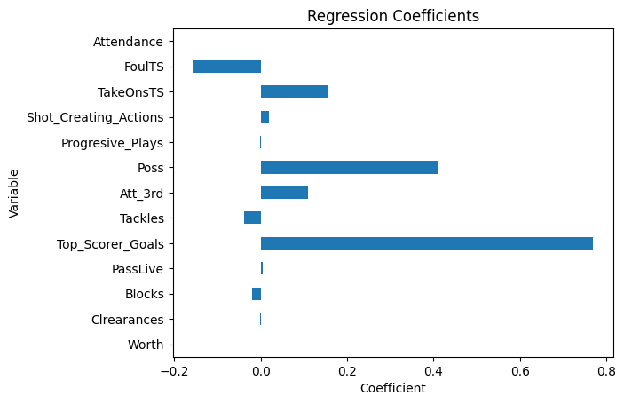

```python
coef = reg.params.drop('Intercept')
coef.plot(kind='barh')
plt.xlabel('Coefficient')
plt.ylabel('Variable')
plt.title('Regression Coefficients')
plt.show()
```

#### This graph shows the [regression coefficents](https://statisticsbyjim.com/glossary/regression-coefficient/) of all the variables that contributed to the model. The larger the bar the larger the impact it has on the model and the sign represents the direction of impact it has on the predicted points. According to the graph, the total worth of the team and the amount of people who came to the games did not affect most team's performances significantly. Addiontally, the number of times a team played on from a foul and got a shot towards the goal and the number of tackles, and the number of blocks made seems to negatively affect the quantity of the predicted number of points. Then the biggest factors that positively affected the amount of points is the number of goals the top scorer scored, possesion, the number of times an offensive player has taken on a defender and taken a shot, and the number of times a player attemted a tackle on the attacking third. This factors show which of them are the most important and which decide who wins the game more often than other factors do.

```python
# create a new column in the data frame to store the predicted values
df['predicted_pts'] = reg.predict(df)

fig = px.scatter(df, x='predicted_pts', y='Pts', title='Predicted vs Actual Pts')
fig.update_xaxes(title="Predicted Points")
fig.update_yaxes(title="Actual Points")
fig.show()
```

[interactive chart not shown]

#### This plot shows the realtionship between the predicted points from the regression and the actuall amount of points that the team has. As shown by the graph, most of the points are mostly accuratly predicted which shows the accuracy and strength of the regression model.

```python
# create a new column in the data frame to store the residuals
df['residuals'] = reg.resid

# create a scatter plot of residuals vs predicted 'Pts'
fig = px.scatter(df, x='predicted_pts', y='residuals', title='Residual Plot')
fig.update_xaxes(title="Predicted Points")
fig.update_yaxes(title="Residuals")

# add a horizontal line at y=0 to indicate the zero residual line
fig.add_shape(type='line', x0=df['predicted_pts'].min(), y0=0, x1=df['predicted_pts'].max(), y1=0, line=dict(color='red'))

fig.show()
```

[interactive chart not shown]

#### This graph shows the residuals vs the predicted points. The resiudal is the difference between the predicted value and actual value. This can be used to see how well the model predicts the data. More about residuals can be found [here](https://www.ncl.ac.uk/webtemplate/ask-assets/external/maths-resources/statistics/regression-and-correlation/residuals.html). This graph shows how the residuals are randomly distributed which shows that the model has predicted the value of the points correctly. Addionally, the points are symetirc arround the residual = 0 line which also supports the argument that the model is accurate. However, one drawback this graph shows is how some points are far from the resiudals = 0 line which means that there are some values that the model does not predict that well, but the majority of the values are predicted accurately.

```python
kmeans = KMeans(n_clusters=5, random_state=0).fit(df[['Poss', 'Worth', 'Progresive_Plays', 'Shot_Creating_Actions', 'Goals']])

# Add the cluster labels to the DataFrame
df['Cluster'] = kmeans.labels_

# Plot the results using Plotly Express
fig = px.scatter(df, x='GD', y='Pts', color='Cluster',
                 hover_data=['Squad', 'CL/REL', 'LgRk'])
fig.update_layout(title='K-means clustering with 5 clusters')
fig.show()
```

[interactive chart not shown]

```python
# Separate the target variable and the features
X = df[['Worth', 'SCA/90', 'PassLive', 'PassDead', 'TakeOnsTS', 'ShotTS', 'FoulTS', 'DefTS', 'GCA/90', '#OfPlayers', 'Age', 'Poss', 'YCard', 'RCard', 'PrgC', 'PrgP', 'Tackles', 'TacklesW', 'Def_3rd', 'Mid_3rd', 'Att_3rd', 'Blocks', 'Interceptions', 'Clrearances', 'Errors', 'Attendance', 'Progresive_Plays', 'TackleWP']]
y = df['GD']

# Split the data into training and test sets
X_train, X_test, y_train, y_test = train_test_split(X, y, test_size=0.40, random_state=42)

# Add the 'Squad' column to the test data set
test_data = X_test.copy()
test_data['Squad'] = df.loc[y_test.index, 'Squad']

# Create the Random Forest Regression model and fit the training data
rf = RandomForestRegressor(n_estimators=100, random_state=42)
rf.fit(X_train, y_train)

# Make predictions on the testing data
y_pred = rf.predict(X_test)

# Evaluate the model using R-squared metric
r2 = rf.score(X_test, y_test)
print(f'R-squared: {r2:.2f}')

# Add the predicted values to the data frame with the 'Squad' column
df_pred = test_data[['Squad']].copy()
df_pred['Predicted_GD'] = y_pred

# Merge with the original data frame to get additional information
df_pred = pd.merge(df_pred, df[['Squad', 'GD']], on='Squad', how='left')

# Create a scatter plot of actual vs. predicted values
fig = px.scatter(df_pred, x='GD', y='Predicted_GD', trendline='ols', hover_data=['Squad'])
fig.update_layout(title='Graph Of Goal Difference vs Predicted Goal Difference')
fig.update_xaxes(title='Goal Differnce')
fig.update_yaxes(title='Predicted Goal Differnce')
fig.show()
```

```
R-squared: 0.77
```

[interactive chart not shown]

The random forest model is a popular machine learning model used for regression. This model has an R^2 value of 0.77, which indicates that it is a good model. The model can be utilized to predict the goal difference a team has when provided with some statistical factors that are critical to a team's performance. As shown in the graph, many of the estimated goal difference values are close to the real goal difference values, indicating the effectiveness of the model in estimating the goal difference. Estimating the goal difference can be useful because it combines both the offensive aspect of the number of goals and the defensive aspect of the number of goals scored against, making it a crucial factor in predicting a team's performance. The random forest model is extremely useful, and more information about it can be found [here](https://towardsdatascience.com/understanding-random-forest-58381e0602d2).